# Chapter 8: An AI Experiment

## Key Ideas

NP-complete, heuristic search, heuristic, Artificial Intelligence (AI)

# Artificial Intelligence

**NP complete** problems are problems whose solutions are hard to find but easy to check. It’s hard to find the optimal solution to a Rubik’s cube, but once you are given a solution, it’s very easy to check.

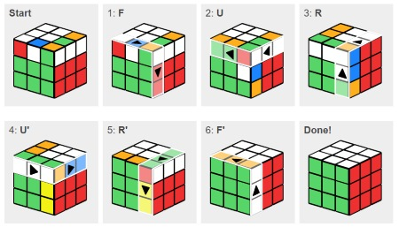

Source: Rubiks-Cube-Solver.com

A **heuristic search** is guided by an informal guess (or **heuristic**) about where to look next. For example, you might search for a solution to an entire Rubik’s cube by looking for moves that solve the corners.

A heuristic search looks for a good solution (solving the corners of the Rubik’s cube)– although it might find an optimal solution (solving the entire cube). A heuristic search is easier and faster than an exact search. We find heuristics by considering simpler, more relaxed versions of the problem (solving the corners rather than solving the entire cube).

**Artificial Intelligence (AI)** is a heuristic search for a solution to an NP-complete problem. The basic steps for creating an AI is to:

1. Specify the problem
2. Represent the problem using the computer
3. Choose a heuristic
4. Develop a heuristic search algorithm
5. Experiment

In what follows, we take you through the basic steps for solving an AI problem.

# Specify the Problem

When customers are unhappy about the service they receive, they submit complaints. We would like to sort customer complaints by priority.

# Represent the problem using the computer

We can represent Customer Feedback as a Document-Term Matrix (DTM). A document-term matrix (DTM) describes the frequency of terms that occur in a collection of documents. In a DTM, rows correspond to documents in the collection and columns correspond to terms. Representing customer feedback as a DTM will allow us to cluster the feedback into groups based on the relative frequency of terms used.

## Access the data

We start by accessing a batch of customer feedback records. These records have been downloaded from an Internet-published location and uploaded to the local cluster for use in this experiment. When in production, data should be accessed directly from the orginial system of record. Updating the data access method should not change the rest of this experiment.

Data Governance Rules:

1. Access all data using SSL
2. Identify customers using only a synthetic identifier
3. Access only the unstructured text content of the feedback (redact any personally-identifiable content)
4. Return only a determination of priority

Note that the system of record has redacted personally-identifiable information in accordance with data governance rule #3 above. In the body of unstructured text, the redacted information is denoted by “xxxx”

Data Features Needed:

- Synthetic customer ID
- Content of the feedback

```r
feedback <- read.csv("https://raw.githubusercontent.com/jerryaoverton/basic-ml-algorithms/master/data/consumer_complaints_population.csv")
data <- as.data.frame(feedback)
#filter the data down to the columns we need for analysis
cols <- c("Complaint.ID", "Product", "Consumer.complaint.narrative")
data <- data[,cols]
data[1,]
```

```
  Complaint.ID     Product
1      2257428 Credit card
                                                            Consumer.complaint.narrative
1 I paid off my full statement balance before due date but I was still charged interest.
```

## Build a Corpus of Customer Feedback

A corpus is a collection of text documents. The corpus allows us to perform document-processing tasks like building document-term matrixes (DTM). We build a coprus using the text from each customer feedback row. We clean the corpus by making all words lowercase, removing punctuation, removing numbers, and removing common, but distracting terms (stop words) like of, and, or the. Finally, we stem words so that words like runs, and running are recognized as being a single term.

```r
#build a corpus (a collection of text documents) from the consumer complaint narrative
#function to check if a package is installed
is_installed <- function(mypkg) is.element(mypkg, installed.packages()[,1])
if(!is_installed("tm")){install.packages("tm")}
library(tm)
corpus <- Corpus(VectorSource(data$Consumer.complaint.narrative))
#clean the corpus:
corpus <- tm_map(corpus, tolower) #make everything lower case
```

```
transformation drops documents
```

```r
corpus <- tm_map(corpus, removePunctuation) #remove punctuation
```

```
transformation drops documents
```

```r
corpus <- tm_map(corpus, removeNumbers) #remove numbers
```

```
transformation drops documents
```

```r
corpus <- tm_map(corpus, removeWords, stopwords('english')) #remove stop words
```

```
transformation drops documents
```

```r
if(!is_installed("SnowballC")){install.packages("SnowballC")}
library(SnowballC)
corpus <- tm_map(corpus, stemDocument, language = "english") #stem the words
```

```
transformation drops documents
```

```r
#take a look at the second document in the corpus
inspect(corpus[1])
```

```
<<SimpleCorpus>>
Metadata:  corpus specific: 1, document level (indexed): 0
Content:  documents: 1

[1] paid full statement balanc due date still charg interest
```

## Build a Document-Term Matrix

A document-term matrix (DTM) describes the frequency of terms that occur in a collection of documents. In a DTM, rows correspond to documents in the collection and columns correspond to terms. Representing customer feedback as a DTM will allow us to cluster the feedback into groups based on the relative frequency of terms used.

```r
#create a document term matrix from the corpus
dtm <- DocumentTermMatrix(corpus)
#remove sparse terms
sparse = .75
dtm <- removeSparseTerms(dtm, sparse)
#convert the document term matrix into a data frame
dtm.m <- as.matrix(dtm)
dtm.df <- as.data.frame(dtm.m)
dtm.df [1:5, 1:10]
```

```
  account compani credit get never payment report time xxxx call
1       0       0      0   0     0       0      0    0    0    0
2       7       2     10   1     1       4     10    2   13    0
3       0       0      0   0     0       0      0    0    0    0
4       1       0      0   1     2       0      0    1   18    3
5       0       0      0   0     1       1      0    0    0    1
```

# Choose a Heuristic

Clustering groups the rows of the customer feedback DTM in such a way that rows in the same group are more similar to each other than to those in other groups. We assume that

1. Each priority class of comments (high, medium, low, etc) have word frequencies and combinations that distinguish them
2. Priority class has a Pareto distribution with most comments being a low priority, high comments being relatively rare, and medium-priority comments being somewhere in between

Given these assumptions, we believe that clustering feedback based on term frequency is a reasonable approximation to the intelligent act of reading the documents and determining a priority

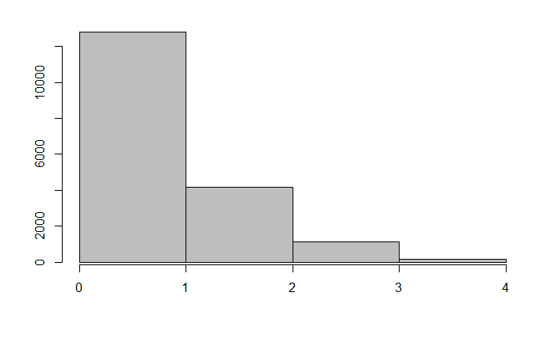

```r
#create clusters from k-means
set.seed(1)
num_clusters = 4
kmeans.result <- kmeans(dtm.df, num_clusters)
#define a function that allows us to plot the clusters using a histogram
int.hist = function(x) {
  barplot(table(factor(x,levels=min(x):max(x))),space=0,xaxt="n");axis(1)
}
int.hist(kmeans.result$cluster)
```

# Develop a heuristic search algorithm

Given the assumptions made when representing the act of prioritization as clustering, we believe that we can arrange the clusters so that the relative frequency matches a Pareto distribution, then interpret priority such that high-priority feedback is very rare, low priority feedback is common, and medium-priority feedback is somewhere in between.

```r
#create priorities based on the clusters
priorities <- kmeans.result$cluster
priorities[priorities==1]<-"L" #low
priorities[priorities==2]<-"M" #medium
priorities[priorities==3]<-"H" #high
priorities[priorities==4]<-"C" #critical
#add the priority assignment to the original data
data$priority <- priorities
data[1:1,]
```

```
  Complaint.ID     Product
1      2257428 Credit card
                                                            Consumer.complaint.narrative
1 I paid off my full statement balance before due date but I was still charged interest.
  priority
1        L
```

# Experiment

To anticipate the consequnces of deploying the AI as built, we need an intuitive understanding of how it decides priority. A profile of the AI gives us information about the factors most influential to the AI and how those factors influence response. The profile allows us to anticipate how the AI will behave when exposed to live data. We profile the AI by building a decision tree that predicts priority the AI assigns based on the the relative word frequencies that the AI considers. The decision tree allows us to understand which word frequencies and cominations are important to determing priority.

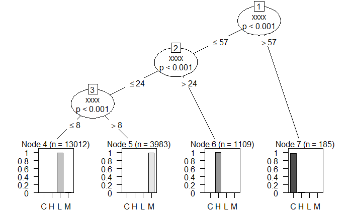

```r
#add the priority assignment to the document term matrix
dtm.df$priority <- as.factor(priorities)
#use a decision tree to analyze the content difference between the clusters
# train a decision tree
library(party)
formula <- priority ~ .
dtree <- ctree(formula, data = dtm.df, controls = ctree_control(maxdepth = 3))
#plot the tree
plot(dtree)
```